# Temporal network analysis

2024-09-09

This page follows analyses and recreates some plots from [Schulz J et al. (2017) PLOS ONE 12(6): e0179915](https://doi.org/10.1371/journal.pone.0179915).

# Basic network summary

## Network size

**Overall network size:** 170 holdings active over the observed time period

| month | holdings active (n) | holdings active (prop.) |
| --- | --- | --- |
| Jan 2019 | 29 | 0.171 |
| Feb 2019 | 10 | 0.059 |
| Mar 2019 | 8 | 0.047 |
| Apr 2019 | 15 | 0.088 |
| May 2019 | 6 | 0.035 |
| Jun 2019 | 16 | 0.094 |
| Jul 2019 | 22 | 0.129 |
| Aug 2019 | 20 | 0.118 |
| Sep 2019 | 18 | 0.106 |
| Oct 2019 | 22 | 0.129 |
| Nov 2019 | 14 | 0.082 |
| Dec 2019 | 18 | 0.106 |

### Holdings active (n)

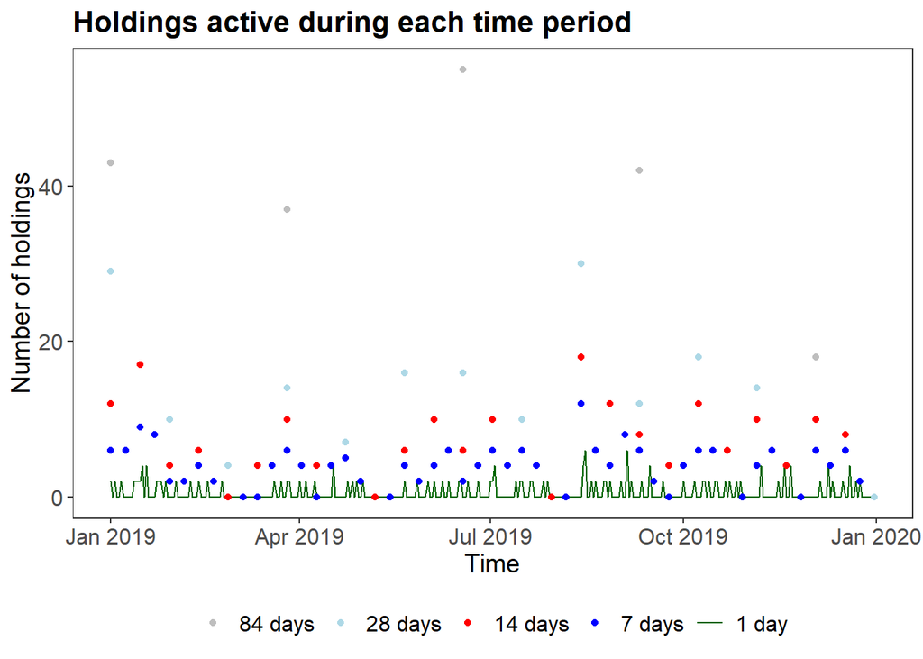

### Holdings active (prop)

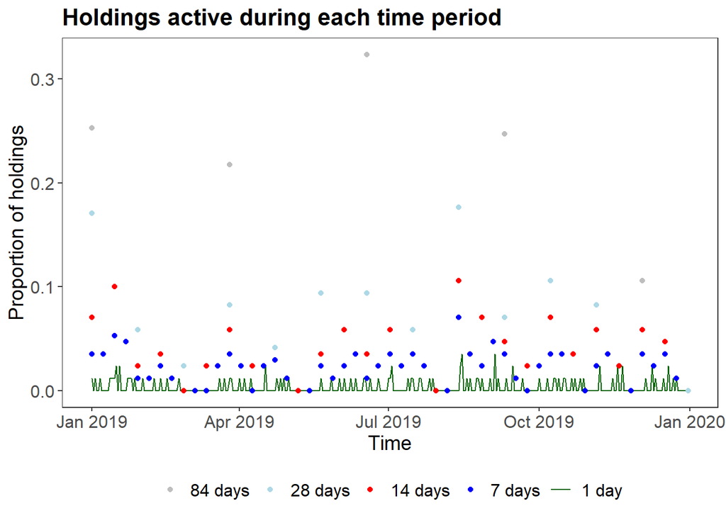

## Movements and edges

**Overall number of movements:** 100 movements over the observed time period  
**Overall number of edges:** 100 different links between holdings over the observed time period  
**Overall edge density:** 0.003 of all possible links between holdings are observed over the observed time period

| month | movements (n) | movements (prop.) | edges (n) | edges (prop.) | edge density (prop.) |
| --- | --- | --- | --- | --- | --- |
| Jan 2019 | 15 | 0.150 | 15 | 0.150 | 0.001 |
| Feb 2019 | 5 | 0.050 | 5 | 0.050 | 0.000 |
| Mar 2019 | 4 | 0.040 | 4 | 0.040 | 0.000 |
| Apr 2019 | 8 | 0.080 | 8 | 0.080 | 0.000 |
| May 2019 | 3 | 0.030 | 3 | 0.030 | 0.000 |
| Jun 2019 | 8 | 0.080 | 8 | 0.080 | 0.000 |
| Jul 2019 | 11 | 0.110 | 11 | 0.110 | 0.000 |
| Aug 2019 | 10 | 0.100 | 10 | 0.100 | 0.000 |
| Sep 2019 | 9 | 0.090 | 9 | 0.090 | 0.000 |
| Oct 2019 | 11 | 0.110 | 11 | 0.110 | 0.000 |
| Nov 2019 | 7 | 0.070 | 7 | 0.070 | 0.000 |
| Dec 2019 | 9 | 0.090 | 9 | 0.090 | 0.000 |

### Movements

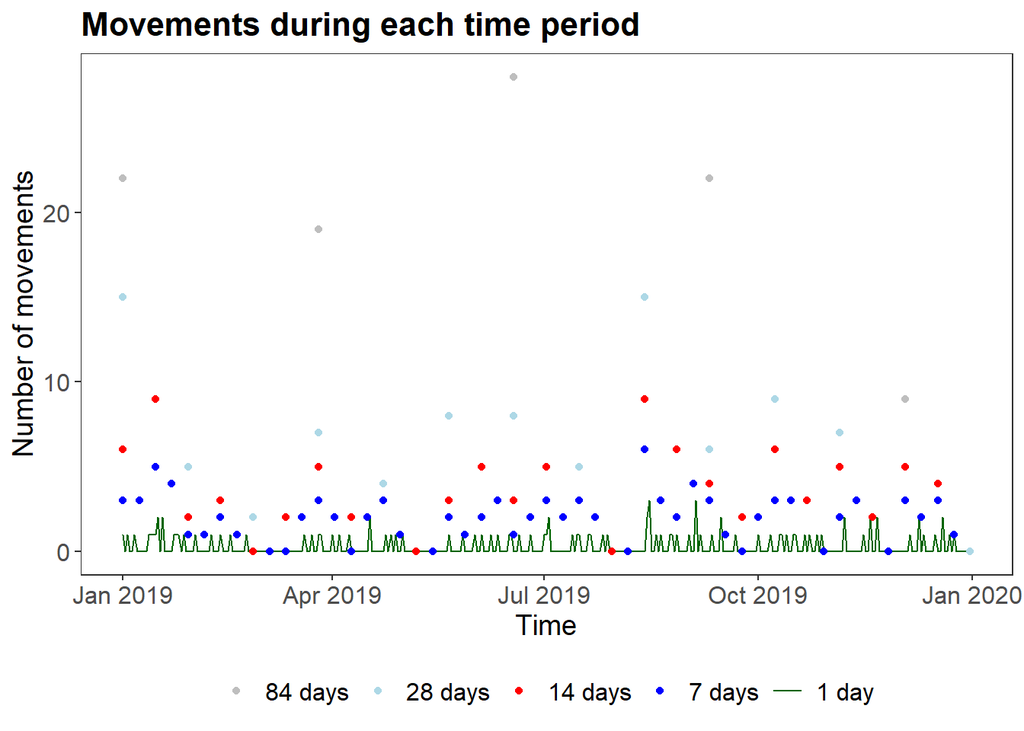

### Movements (prop.)

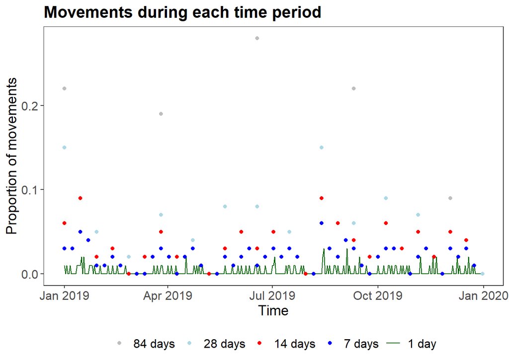

### Edges

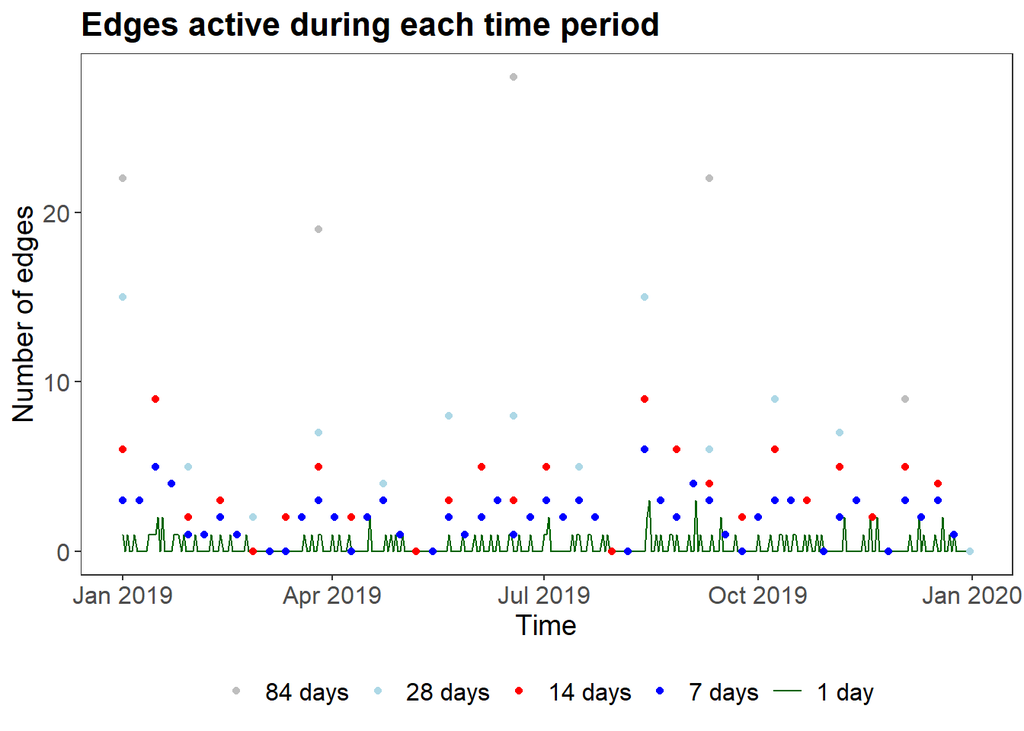

### Edges (prop.)

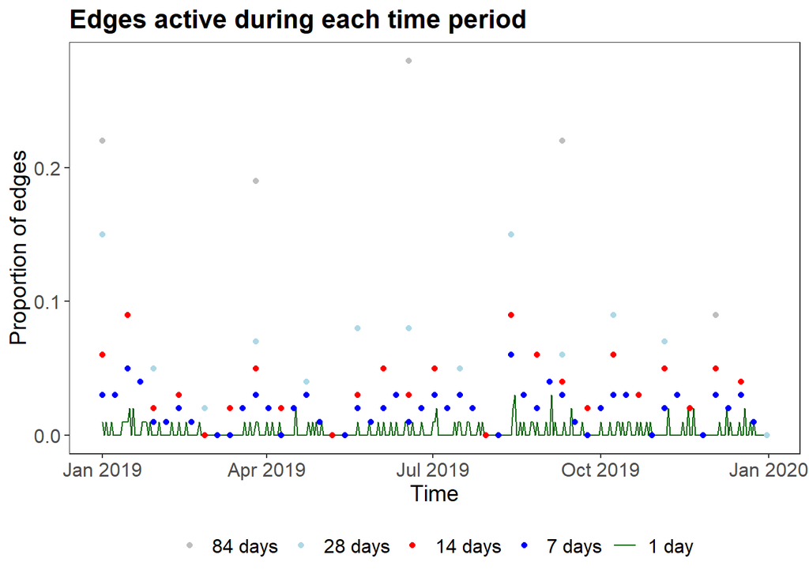

### Density

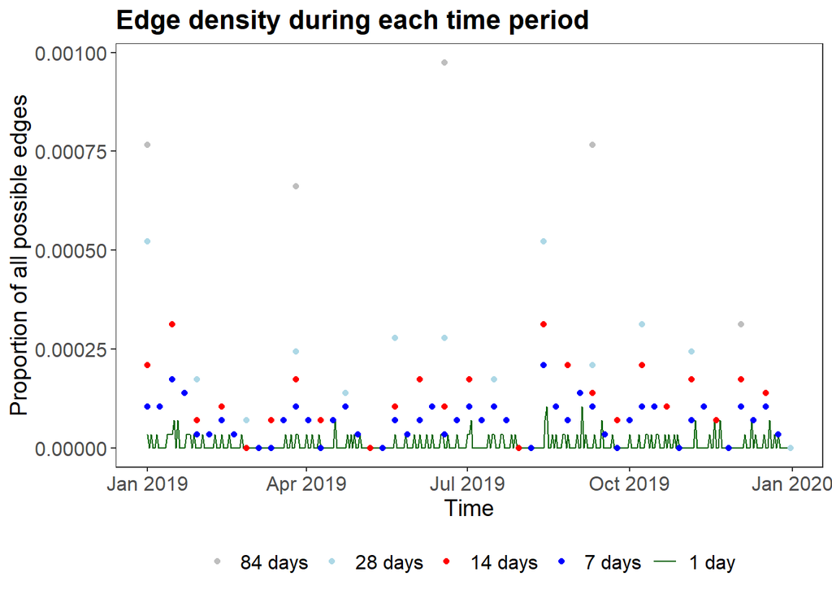

## Movement weights (batch sizes)

| month | min | Q1 | median | mean | Q3 | max |
| --- | --- | --- | --- | --- | --- | --- |
| Jan 2019 | 42 | 54.50 | 74.0 | 91.800 | 115.50 | 185 |
| Feb 2019 | 46 | 73.00 | 97.0 | 96.800 | 108.00 | 160 |
| Mar 2019 | 30 | 39.75 | 50.5 | 64.250 | 75.00 | 126 |
| Apr 2019 | 33 | 39.75 | 53.5 | 75.500 | 98.50 | 157 |
| May 2019 | 89 | 101.00 | 113.0 | 128.333 | 148.00 | 183 |
| Jun 2019 | 59 | 120.75 | 140.0 | 132.000 | 162.00 | 178 |
| Jul 2019 | 39 | 71.50 | 90.0 | 99.182 | 123.50 | 181 |
| Aug 2019 | 31 | 51.50 | 104.5 | 98.800 | 128.25 | 177 |
| Sep 2019 | 41 | 108.00 | 122.0 | 124.778 | 147.00 | 183 |
| Oct 2019 | 47 | 90.50 | 125.0 | 124.455 | 166.00 | 187 |
| Nov 2019 | 76 | 116.50 | 134.0 | 135.143 | 159.00 | 185 |
| Dec 2019 | 42 | 65.00 | 151.0 | 123.556 | 159.00 | 172 |

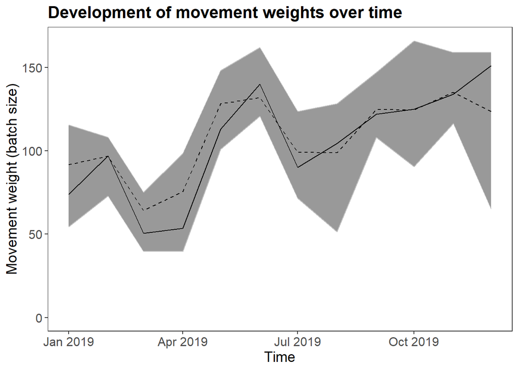

# Static network analysis (monthly snapshots)

## Component analysis

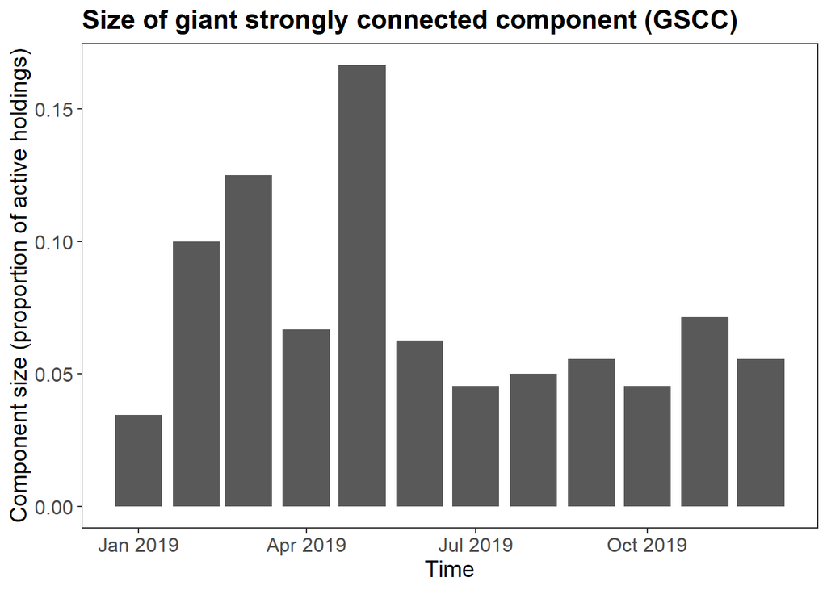

The largest giant strongly connected component (GSCC) is the largest number of nodes (holdings) that can all reach each other by some directed path of movements. This means that any node in that set could indirectly infect any other, or that a single source outbreak within the component could theoretically infect anything else within that component.

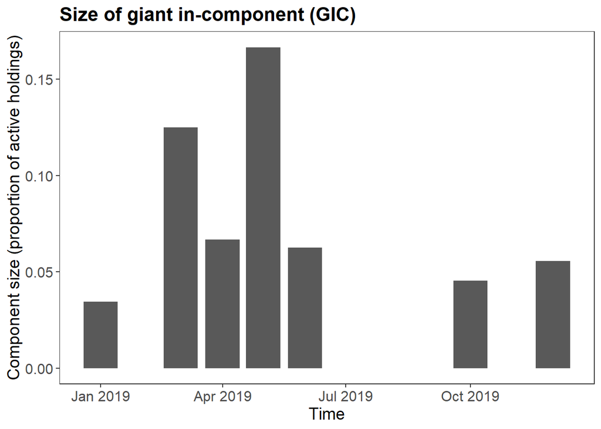

The giant in-component (GIC) consists of all nodes (holdings) that can reach the GSCC, but are not part of it, because there is no directed path from the GSCC to these nodes. This means that any holding in this set could infect holdings in the GSCC, but not be infected by them.

[figure not shown]

Conversely, the giant out-component (GOC) consists of all nodes (holdings) that can be reached from the GSCC, but are not part of it, because there is no directed path from these nodes to the GSCC. This means that any holding in this set could be infected by holdings in the GSCC, but not infect them.

## Loyalty

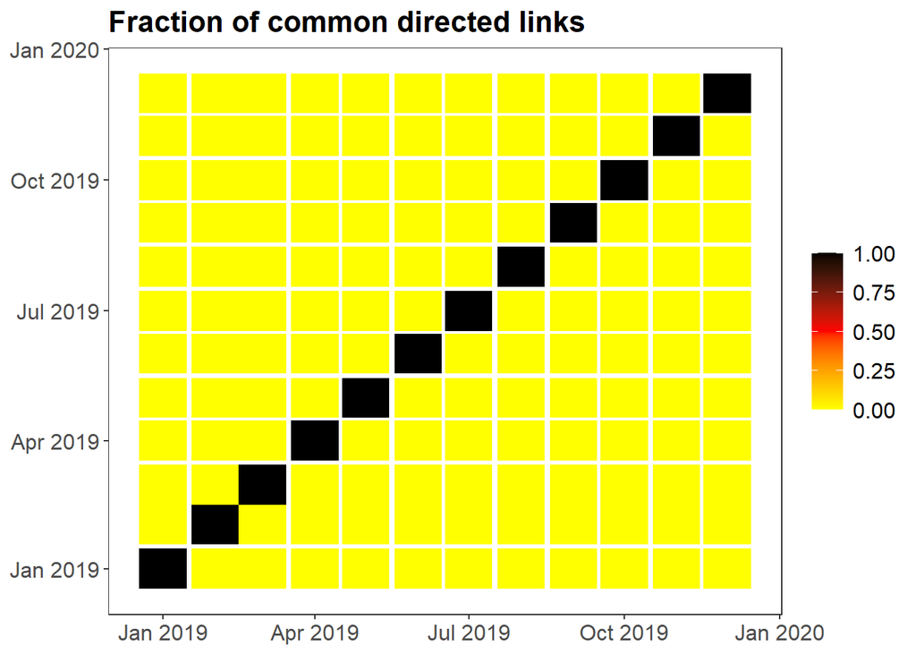

This is a measure of consistency in the network between different points in time. Darker colours indicate a larger proportion of trades that are in common between two months. The black diagonal indicates that each month’s movements are identical to themselves.